# Part I - Ford GoBike System Dataset Exploration

## by EYAMBE MPOULI Boris Claude

- Introduction
- Part I - Preliminary Wrangling
- Part II - Univariate Exploration
- Part III - Bivariate Exploration
- Part IV - Multivariate Exploration
- Part V - Conclusion

## Introduction

> This dataset is taken from Ford GoBike a public bicycle sharing system in California, the data contained information about GoBike members and all trips that were taken by them in February 2019.

## Preliminary Wrangling

```python
# import all packages and set plots to be embedded inline
import numpy as np
import pandas as pd
import matplotlib.pyplot as plt
import seaborn as sns
import warnings
warnings.filterwarnings("ignore")

%matplotlib inline
```

```python
# read the data from .csv file
df = pd.read_csv('201902-fordgobike-tripdata.csv')
df.head()
```

|  | duration_sec | start_time | end_time | start_station_id | start_station_name | start_station_latitude | start_station_longitude | end_station_id | end_station_name | end_station_latitude | end_station_longitude | bike_id | user_type | member_birth_year | member_gender | bike_share_for_all_trip |
| --- | --- | --- | --- | --- | --- | --- | --- | --- | --- | --- | --- | --- | --- | --- | --- | --- |
| 0 | 52185 | 2019-02-28 17:32:10.1450 | 2019-03-01 08:01:55.9750 | 21.0 | Montgomery St BART Station (Market St at 2nd St) | 37.789625 | -122.400811 | 13.0 | Commercial St at Montgomery St | 37.794231 | -122.402923 | 4902 | Customer | 1984.0 | Male | No |
| 1 | 42521 | 2019-02-28 18:53:21.7890 | 2019-03-01 06:42:03.0560 | 23.0 | The Embarcadero at Steuart St | 37.791464 | -122.391034 | 81.0 | Berry St at 4th St | 37.775880 | -122.393170 | 2535 | Customer | NaN | NaN | No |
| 2 | 61854 | 2019-02-28 12:13:13.2180 | 2019-03-01 05:24:08.1460 | 86.0 | Market St at Dolores St | 37.769305 | -122.426826 | 3.0 | Powell St BART Station (Market St at 4th St) | 37.786375 | -122.404904 | 5905 | Customer | 1972.0 | Male | No |
| 3 | 36490 | 2019-02-28 17:54:26.0100 | 2019-03-01 04:02:36.8420 | 375.0 | Grove St at Masonic Ave | 37.774836 | -122.446546 | 70.0 | Central Ave at Fell St | 37.773311 | -122.444293 | 6638 | Subscriber | 1989.0 | Other | No |
| 4 | 1585 | 2019-02-28 23:54:18.5490 | 2019-03-01 00:20:44.0740 | 7.0 | Frank H Ogawa Plaza | 37.804562 | -122.271738 | 222.0 | 10th Ave at E 15th St | 37.792714 | -122.248780 | 4898 | Subscriber | 1974.0 | Male | Yes |

```python
#here we look for the dimensions of our dataset
df.shape
```

```
(183412, 16)
```

```python
#here we look the features of our dataset
df.info()
```

```
<class 'pandas.core.frame.DataFrame'>
RangeIndex: 183412 entries, 0 to 183411
Data columns (total 16 columns):
 #   Column                   Non-Null Count   Dtype
---  ------                   --------------   -----
 0   duration_sec             183412 non-null  int64
 1   start_time               183412 non-null  object
 2   end_time                 183412 non-null  object
 3   start_station_id         183215 non-null  float64
 4   start_station_name       183215 non-null  object
 5   start_station_latitude   183412 non-null  float64
 6   start_station_longitude  183412 non-null  float64
 7   end_station_id           183215 non-null  float64
 8   end_station_name         183215 non-null  object
 9   end_station_latitude     183412 non-null  float64
 10  end_station_longitude    183412 non-null  float64
 11  bike_id                  183412 non-null  int64
 12  user_type                183412 non-null  object
 13  member_birth_year        175147 non-null  float64
 14  member_gender            175147 non-null  object
 15  bike_share_for_all_trip  183412 non-null  object
dtypes: float64(7), int64(2), object(7)
memory usage: 22.4+ MB
```

```python
#checking for the missing values
df.isna().sum()
```

```
duration_sec                  0
start_time                    0
end_time                      0
start_station_id            197
start_station_name          197
start_station_latitude        0
start_station_longitude       0
end_station_id              197
end_station_name            197
end_station_latitude          0
end_station_longitude         0
bike_id                       0
user_type                     0
member_birth_year          8265
member_gender              8265
bike_share_for_all_trip       0
dtype: int64
```

```python
#checking for duplicates
df.duplicated().sum()
```

```
0
```

```python
#looking for basic statistics for numerical variables
df.describe()
```

|  | duration_sec | start_station_id | start_station_latitude | start_station_longitude | end_station_id | end_station_latitude | end_station_longitude | bike_id | member_birth_year |
| --- | --- | --- | --- | --- | --- | --- | --- | --- | --- |
| count | 183412.000000 | 183215.000000 | 183412.000000 | 183412.000000 | 183215.000000 | 183412.000000 | 183412.000000 | 183412.000000 | 175147.000000 |
| mean | 726.078435 | 138.590427 | 37.771223 | -122.352664 | 136.249123 | 37.771427 | -122.352250 | 4472.906375 | 1984.806437 |
| std | 1794.389780 | 111.778864 | 0.099581 | 0.117097 | 111.515131 | 0.099490 | 0.116673 | 1664.383394 | 10.116689 |
| min | 61.000000 | 3.000000 | 37.317298 | -122.453704 | 3.000000 | 37.317298 | -122.453704 | 11.000000 | 1878.000000 |
| 25% | 325.000000 | 47.000000 | 37.770083 | -122.412408 | 44.000000 | 37.770407 | -122.411726 | 3777.000000 | 1980.000000 |
| 50% | 514.000000 | 104.000000 | 37.780760 | -122.398285 | 100.000000 | 37.781010 | -122.398279 | 4958.000000 | 1987.000000 |
| 75% | 796.000000 | 239.000000 | 37.797280 | -122.286533 | 235.000000 | 37.797320 | -122.288045 | 5502.000000 | 1992.000000 |
| max | 85444.000000 | 398.000000 | 37.880222 | -121.874119 | 398.000000 | 37.880222 | -121.874119 | 6645.000000 | 2001.000000 |

```python
#looking for bassic statistics for categorical values
df.describe(include=['O'])
```

|  | start_time | end_time | start_station_name | end_station_name | user_type | member_gender | bike_share_for_all_trip |
| --- | --- | --- | --- | --- | --- | --- | --- |
| count | 183412 | 183412 | 183215 | 183215 | 183412 | 175147 | 183412 |
| unique | 183401 | 183397 | 329 | 329 | 2 | 3 | 2 |
| top | 2019-02-22 20:11:42.2560 | 2019-02-12 17:52:28.0280 | Market St at 10th St | San Francisco Caltrain Station 2 (Townsend St... | Subscriber | Male | No |
| freq | 2 | 2 | 3904 | 4857 | 163544 | 130651 | 166053 |

### What is the structure of your dataset?

Our dataset has 183412 rows and 16 columns.

There are a few missing values in start_station_id, start_station_name, end_station_id, end_station_name, member_birth_year, member_gender columns, and since we don’t have any additional resources to fill these missing values, and the fact that they are very few compare to the large amount of data we have, we will remove them.

### Data Issues

#### Quality issues

- drop the missing values
- convert duration from seconds to minutes, rename the column and change its data type
- create trip_start_time, trip_start_day and trip_start_period from start_time column
- create trip_end_time, trip_end_day and trip_end_period from end_time column
- create member_age from member_birth_year
- drop irrelevant columns

### Cleaning

```python
#make a copy of our dataset for the cleaning purpose
df_clean = df.copy()
```

#### Task 1

#### Define :

Here we will drop the missing values from our dataset since they are less compare to the amount of our data

#### Code :

```python
#here we drop missing values from our dataset
df_clean = df_clean.dropna()
```

#### Test

```python
#here we check if missing values remains
df_clean.isna().sum()
```

```
duration_sec               0
start_time                 0
end_time                   0
start_station_id           0
start_station_name         0
start_station_latitude     0
start_station_longitude    0
end_station_id             0
end_station_name           0
end_station_latitude       0
end_station_longitude      0
bike_id                    0
user_type                  0
member_birth_year          0
member_gender              0
bike_share_for_all_trip    0
dtype: int64
```

#### Task 2

#### Define:

- convert duration of trip from seconds to minutes
- change the data type

#### Code :

```python
# here we convert the duration from seconds to minutes
df_clean['duration_min'] = df_clean['duration_sec'] / 60
df_clean['duration_min'] = df_clean['duration_min'].astype(int)
```

#### Test

```python
# here we check our dataset features to ensure that duration_min has been created
df_clean.info()
```

```
<class 'pandas.core.frame.DataFrame'>
Int64Index: 174952 entries, 0 to 183411
Data columns (total 17 columns):
 #   Column                   Non-Null Count   Dtype
---  ------                   --------------   -----
 0   duration_sec             174952 non-null  int64
 1   start_time               174952 non-null  object
 2   end_time                 174952 non-null  object
 3   start_station_id         174952 non-null  float64
 4   start_station_name       174952 non-null  object
 5   start_station_latitude   174952 non-null  float64
 6   start_station_longitude  174952 non-null  float64
 7   end_station_id           174952 non-null  float64
 8   end_station_name         174952 non-null  object
 9   end_station_latitude     174952 non-null  float64
 10  end_station_longitude    174952 non-null  float64
 11  bike_id                  174952 non-null  int64
 12  user_type                174952 non-null  object
 13  member_birth_year        174952 non-null  float64
 14  member_gender            174952 non-null  object
 15  bike_share_for_all_trip  174952 non-null  object
 16  duration_min             174952 non-null  int32
dtypes: float64(7), int32(1), int64(2), object(7)
memory usage: 23.4+ MB
```

#### Task 3

#### Define:

Use start_time to:

- create trip_start_time
- create trip_start_day
- create trip_start_period

#### Code :

```python
# create period column from the start date
df_clean['trip_start_time']   =  pd.to_datetime(df_clean['start_time']).dt.hour
df_clean['trip_start_day']    =  pd.to_datetime(df_clean['start_time']).dt.day_name()
df_clean['trip_start_period'] =  df_clean.apply(lambda row:
                                 'Morning' if (row['trip_start_time'] < 12)
                                  else ('Afternoon' if row['trip_start_time'] >= 12 and row['trip_start_time'] <=18
                                  else 'Night'), axis=1)
```

#### Test

```python
# here we check if the columns were created
df_clean.info()
```

```
<class 'pandas.core.frame.DataFrame'>
Int64Index: 174952 entries, 0 to 183411
Data columns (total 20 columns):
 #   Column                   Non-Null Count   Dtype
---  ------                   --------------   -----
 0   duration_sec             174952 non-null  int64
 1   start_time               174952 non-null  object
 2   end_time                 174952 non-null  object
 3   start_station_id         174952 non-null  float64
 4   start_station_name       174952 non-null  object
 5   start_station_latitude   174952 non-null  float64
 6   start_station_longitude  174952 non-null  float64
 7   end_station_id           174952 non-null  float64
 8   end_station_name         174952 non-null  object
 9   end_station_latitude     174952 non-null  float64
 10  end_station_longitude    174952 non-null  float64
 11  bike_id                  174952 non-null  int64
 12  user_type                174952 non-null  object
 13  member_birth_year        174952 non-null  float64
 14  member_gender            174952 non-null  object
 15  bike_share_for_all_trip  174952 non-null  object
 16  duration_min             174952 non-null  int32
 17  trip_start_time          174952 non-null  int64
 18  trip_start_day           174952 non-null  object
 19  trip_start_period        174952 non-null  object
dtypes: float64(7), int32(1), int64(3), object(9)
memory usage: 27.4+ MB
```

#### Task 4

#### Define:

Use end_time to:

- create trip_end_time
- create trip_end_day
- create trip_end_period

#### Code :

```python
# create period column from the end date
df_clean['trip_end_time']   =  pd.to_datetime(df_clean['end_time']).dt.hour
df_clean['trip_end_day']    =  pd.to_datetime(df_clean['end_time']).dt.day_name()
df_clean['trip_end_period'] =  df_clean.apply(lambda row:
                                 'Morning' if (row['trip_end_time'] < 12)
                                  else ('Afternoon' if row['trip_end_time'] >= 12 and row['trip_end_time'] <=18
                                  else 'Night'), axis=1)
```

#### Test

```python
# here we check if the columns were created
df_clean.info()
```

```
<class 'pandas.core.frame.DataFrame'>
Int64Index: 174952 entries, 0 to 183411
Data columns (total 23 columns):
 #   Column                   Non-Null Count   Dtype
---  ------                   --------------   -----
 0   duration_sec             174952 non-null  int64
 1   start_time               174952 non-null  object
 2   end_time                 174952 non-null  object
 3   start_station_id         174952 non-null  float64
 4   start_station_name       174952 non-null  object
 5   start_station_latitude   174952 non-null  float64
 6   start_station_longitude  174952 non-null  float64
 7   end_station_id           174952 non-null  float64
 8   end_station_name         174952 non-null  object
 9   end_station_latitude     174952 non-null  float64
 10  end_station_longitude    174952 non-null  float64
 11  bike_id                  174952 non-null  int64
 12  user_type                174952 non-null  object
 13  member_birth_year        174952 non-null  float64
 14  member_gender            174952 non-null  object
 15  bike_share_for_all_trip  174952 non-null  object
 16  duration_min             174952 non-null  int32
 17  trip_start_time          174952 non-null  int64
 18  trip_start_day           174952 non-null  object
 19  trip_start_period        174952 non-null  object
 20  trip_end_time            174952 non-null  int64
 21  trip_end_day             174952 non-null  object
 22  trip_end_period          174952 non-null  object
dtypes: float64(7), int32(1), int64(4), object(11)
memory usage: 31.4+ MB
```

#### Task 5

#### Define:

- create member_age by calculate the difference between 2019 and member_birth_year

#### Code :

```python
#create member_age column by calculate the difference between 2019 and member_birth_year
df_clean['member_age'] = 2019 - df_clean['member_birth_year'].astype(int)
```

#### Test

```python
#we check if member_age was created
df_clean.info()
```

```
<class 'pandas.core.frame.DataFrame'>
Int64Index: 174952 entries, 0 to 183411
Data columns (total 24 columns):
 #   Column                   Non-Null Count   Dtype
---  ------                   --------------   -----
 0   duration_sec             174952 non-null  int64
 1   start_time               174952 non-null  object
 2   end_time                 174952 non-null  object
 3   start_station_id         174952 non-null  float64
 4   start_station_name       174952 non-null  object
 5   start_station_latitude   174952 non-null  float64
 6   start_station_longitude  174952 non-null  float64
 7   end_station_id           174952 non-null  float64
 8   end_station_name         174952 non-null  object
 9   end_station_latitude     174952 non-null  float64
```

[output cut: 16 more lines]

#### Task 6

#### Define:

- drop the irrelevant columns

#### Code :

```python
# here we drop the columns that we found irrelevant for our work
df_clean.drop(['start_time','member_birth_year', 'duration_sec', 'end_time', 'start_station_id',
               'start_station_latitude', 'start_station_longitude', 'end_station_id',
               'end_station_latitude','end_station_longitude', 'bike_id'], axis=1, inplace=True)
```

#### Test

```python
#we test if the irrelevant columns were removed
df_clean.info()
```

```
<class 'pandas.core.frame.DataFrame'>
Int64Index: 174952 entries, 0 to 183411
Data columns (total 13 columns):
 #   Column                   Non-Null Count   Dtype
---  ------                   --------------   -----
 0   start_station_name       174952 non-null  object
 1   end_station_name         174952 non-null  object
 2   user_type                174952 non-null  object
 3   member_gender            174952 non-null  object
 4   bike_share_for_all_trip  174952 non-null  object
 5   duration_min             174952 non-null  int32
 6   trip_start_time          174952 non-null  int64
 7   trip_start_day           174952 non-null  object
 8   trip_start_period        174952 non-null  object
 9   trip_end_time            174952 non-null  int64
 10  trip_end_day             174952 non-null  object
 11  trip_end_period          174952 non-null  object
 12  member_age               174952 non-null  int32
dtypes: int32(2), int64(2), object(9)
memory usage: 17.4+ MB
```

```python
# here we save the clean data
df_clean.to_csv('fordgobike_clean.csv', index=False)
```

### What is/are the main feature(s) of interest in your dataset?

> We want to find out the trends in GoBike customers behaviour to be able to improve the business. So our main focus is to find what features impact the most trips in terms of duration, time period of day (start and end), day of the week (start and end), and members characteristics such as gender, type, and age?

### What features in the dataset do you think will help support your investigation into your feature(s) of interest?

> Since we don't really have a question to investigate, we will use most of the features duration_min, user_type, member_gender, trip_days, trip_periods, member_age as we believe it will help our investigation.

Table of content

## Univariate Exploration

> In this section, investigate distributions of individual variables. If you see unusual points or outliers, take a deeper look to clean things up and prepare yourself to look at relationships between variables.

> In this section, we will explore each variable separately to check the distribution, and the presence of unusual points or outliers.

### Trips Durations

```python
# here we show basic statistics for the duration_min column
df_clean['duration_min'].describe()
```

```
count    174952.000000
mean         11.241461
std          27.371269
min           1.000000
25%           5.000000
50%           8.000000
75%          13.000000
max        1409.000000
Name: duration_min, dtype: float64
```

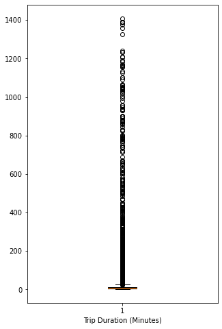

```python
# here we check the distribution of the duration_min column with the boxplot
plt.figure(figsize=[5,8])
plt.boxplot(df_clean['duration_min'])
plt.xlabel('Trip Duration (Minutes)');
```

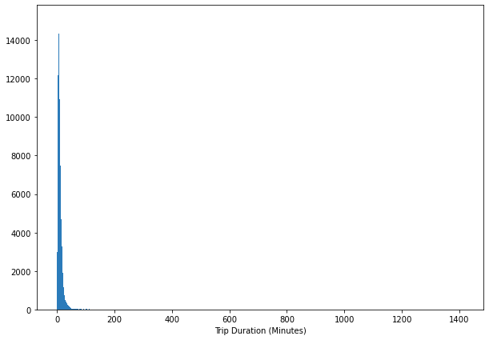

```python
#Here we check the distribution of the duration_min column with his histogram
plt.figure(figsize=[10,7])
plt.xlabel('Trip Duration (Minutes)')
# specifying the number of bins in the histgram
bins = np.arange(df_clean['duration_min'].min(), df_clean['duration_min'].max()+5, 1)
plt.hist(data = df_clean, x = 'duration_min', bins=bins, color = sns.color_palette('Blues')[4]);
```

> From the boxplot above we can see there are outliers in the data, and seeing the histogram the data is highly skewed to the right.

```python
# here we look at the statitics for the duration_min column focusing at the first 99% of the data
df_clean['duration_min'].describe(percentiles=[.99])
```

```
count    174952.000000
mean         11.241461
std          27.371269
min           1.000000
50%           8.000000
99%          52.000000
max        1409.000000
Name: duration_min, dtype: float64
```

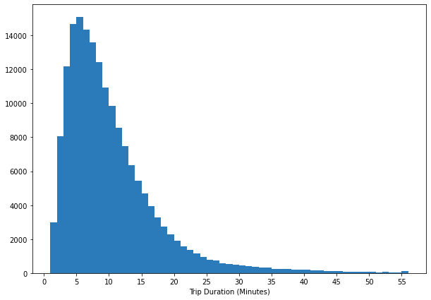

```python
# here we show the histogram of the duration_min column focusing in the first 99% of the data
plt.figure(figsize=[10,7])
plt.xlabel('Trip Duration (Minutes)')
bins = np.arange(df_clean['duration_min'].min(), df_clean['duration_min'].quantile(0.99)+5, 1)
#  specifying the ticks gaps
plt.xticks(np.arange(0, 60, 5), np.arange(0, 60, 5));
plt.hist(data = df_clean, x = 'duration_min', bins=bins, color = sns.color_palette('Blues')[4]);
```

> 99% of the data has a duration less than 52 minutes, so focusing on the 99% of the data we can see in the plot above members’ bike trips usually take from 5 minutes to 15 minutes, and it’s rare they take more than 30 minutes.

### Trips Days

```python
# here we show basic statistics for the categorical columns trip_start_day and trip_start_end
df_clean.describe(include=['O'])[['trip_start_day','trip_end_day']]
```

|  | trip_start_day | trip_end_day |
| --- | --- | --- |
| count | 174952 | 174952 |
| unique | 7 | 7 |
| top | Thursday | Thursday |
| freq | 33712 | 33707 |

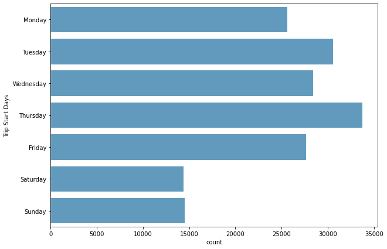

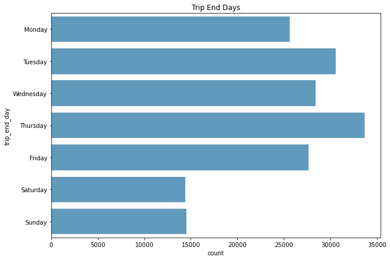

```python
#here we show distributions of trip_start_day and trip_end_day for each weekdays
plt.figure(figsize=[10,7])
sns.countplot(data=df_clean, y='trip_start_day', color = sns.color_palette('Blues')[3],
              order=['Monday', 'Tuesday', 'Wednesday', 'Thursday', 'Friday', 'Saturday', 'Sunday'])
plt.ylabel('Trip Start Days');


plt.figure(figsize=[10,7])
sns.countplot(data=df_clean, y='trip_end_day', color = sns.color_palette('Blues')[3],
              order=['Monday', 'Tuesday', 'Wednesday', 'Thursday', 'Friday', 'Saturday', 'Sunday'])
plt.title('Trip End Days');
```

### Members

#### Members Type

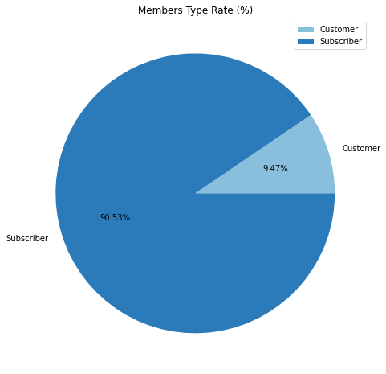

```python
#here we show the proportions for user_type values column using a pieplot
df_clean.groupby(['user_type']).count().plot(kind='pie',
                                             labels=['Customer', 'Subscriber'],
                                             y='trip_end_time',
                                             title="Members Type Rate (%)",
                                             autopct='%.2f%%',
                                             colors = [sns.color_palette('Blues')[2], sns.color_palette('Blues')[4]],
                                             label="",
                                             figsize=(10, 8));
```

> From the plot above we can see that a high percentage of GoBike members **90.53%** are Subscribers while only **9.47%** are Customers.

#### Members Gender

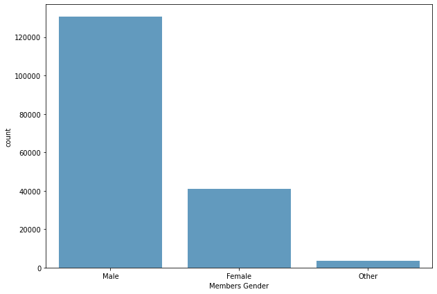

```python
#here we show the distribution of the member_gender values using a seaborn counplot
plt.figure(figsize=[10,7])
sns.countplot(data=df_clean, x='member_gender',
              order= df_clean['member_gender'].value_counts().index,
              color = sns.color_palette('Blues')[3])
plt.xlabel('Members Gender');
```

> From the plot above we can see that the majority of GoBike members are Male, and the difference between the number of Male and Female is big (> 80.000).

#### Members Age

```python
#here we show basic statistics for the member_age column
df_clean['member_age'].describe()
```

```
count    174952.000000
mean         34.196865
std          10.118731
min          18.000000
25%          27.000000
50%          32.000000
75%          39.000000
max         141.000000
Name: member_age, dtype: float64
```

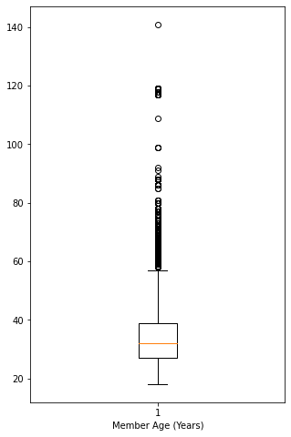

```python
#here we show a first distribution of the member_age column using a boxplot
plt.figure(figsize=[5,8])
plt.boxplot(df_clean['member_age'])
plt.xlabel('Member Age (Years)');
```

> From the boxplot above we can see there are outliers in the data, there are a few records where members age is higher than 80.

```python
#since there are some outliers, here we show basic statistics for the first 99 percentile
df_clean['member_age'].describe(percentiles=[.99])
```

```
count    174952.000000
mean         34.196865
std          10.118731
min          18.000000
50%          32.000000
99%          64.000000
max         141.000000
Name: member_age, dtype: float64
```

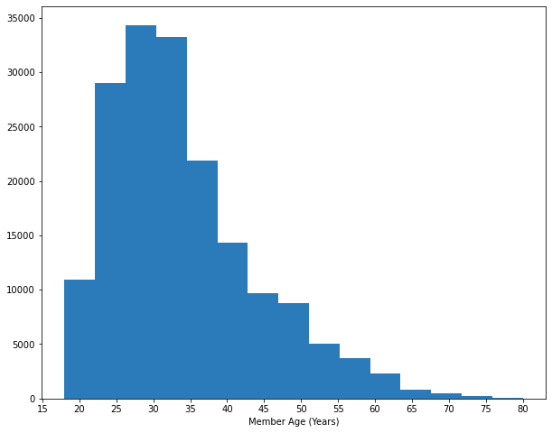

```python
#here we show the member_age distribution focusing in the 99 percentile
plt.figure(figsize=[10,8])
plt.xlabel('Member Age (Years)')
plt.xticks(np.arange(0, 90, 5), np.arange(0, 90, 5));
plt.hist(data = df_clean[df_clean['member_age'] <= 80], x = 'member_age',
         bins=15, color = sns.color_palette('Blues')[4]);
```

### Bike Share For All Trip

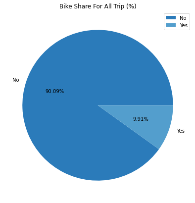

```python
#here we show values proportions for the bike_share_for_all_trip feature
df_clean.groupby(['bike_share_for_all_trip']).count().plot(
    kind='pie', labels=['No', 'Yes'], y='trip_end_time',
    title="Bike Share For All Trip (%)", autopct='%.2f%%',
    colors = [sns.color_palette('Blues')[4], sns.color_palette('Blues')[3]],
    label="", figsize=(10, 7));
```

> From the plot above we can see that a high percentage of GoBike members **90.09%** don't use GoBike share for their entire trip, while only **9.91%** are using it for their entire trip.

### Trip Period

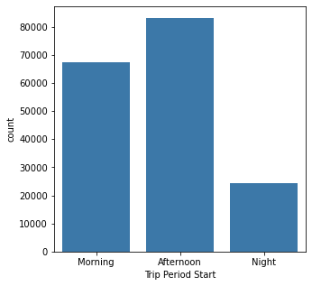

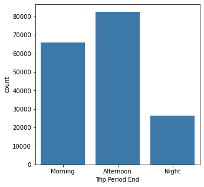

```python
#here we show countplots for trip_start_period and trip_end_period
plt.figure(figsize=[5,5])
sns.countplot(data=df_clean, x='trip_start_period', order=['Morning', 'Afternoon', 'Night'],
              color = sns.color_palette('Blues')[4])
plt.xlabel('Trip Period Start');

plt.figure(figsize=[5,5])
sns.countplot(data=df_clean, x='trip_end_period', order=['Morning', 'Afternoon', 'Night'],
              color = sns.color_palette('Blues')[4])
plt.xlabel('Trip Period End');
```

> From the plot above we can see that members usually start and end bike tripes in the Morning and at Afternoon, and sometimes they in the Night. And once again we can see that both trip_start_period and trip_end_period have the same distribution.

### Start Station Name

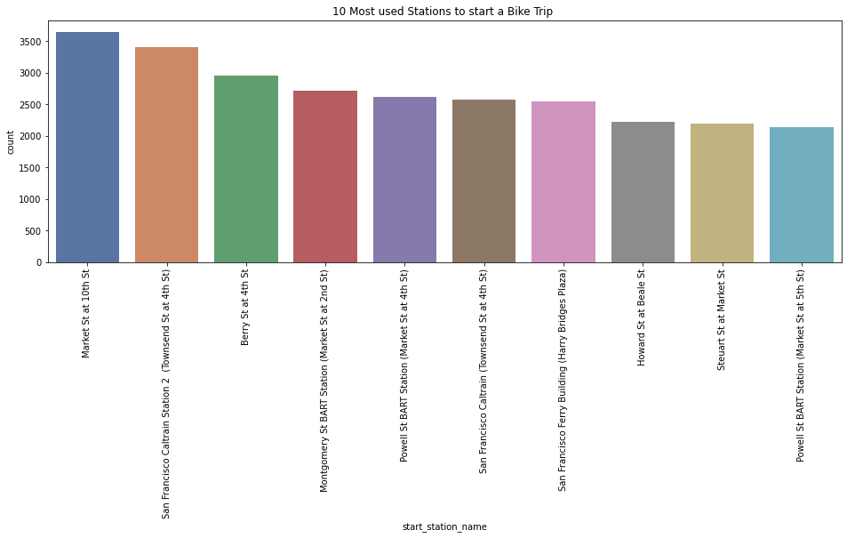

```python
#here we show the top 10 stations to start a trip
fig, ax = plt.subplots(figsize = (16,5))
ax = sns.countplot(x = "start_station_name", data = df_clean,
                   order=df_clean.start_station_name.value_counts().iloc[:10].index,
                   palette = "deep")
ax.set_title("10 Most used Stations to start a Bike Trip ");
plt.xticks(rotation = 90);
```

### End Station Name

[figure not shown]

```python
#here we show the top 10 stations to end a trip
fig, ax = plt.subplots(figsize = (16,5))
ax = sns.countplot(x = "end_station_name", data = df_clean,
                   order=df_clean.end_station_name.value_counts().iloc[:10].index,
                   palette = "deep")
ax.set_title("10 Most used Stations to start a Bike Trip ");
plt.xticks(rotation = 90);
```

###### From the plots above we can see that:

> GoBike members usually start their trips at:
> - Market St at 10th St
> - San Francisco Caltrain Station 2 (Townsend St at 4th St)
> - Berry St at 4th St

> And usually end their trips at:
> - San Francisco Caltrain Station 2 (Townsend St at 4th St)
> - Market St at 10th St
> - Montgomery St BART Station (Market St at 2nd St)

### Discuss the distribution(s) of your variable(s) of interest. Were there any unusual points? Did you need to perform any transformations?

> Checking all data no transformation was needed.

### Of the features you investigated, were there any unusual distributions? Did you perform any operations on the data to tidy, adjust, or change the form of the data? If so, why did you do this?

> For the trip duration:
> - Since there were some outliers, we focused on 99% of the data which has a duration less than 52 minutes, while the maximum was 1409 minutes.

> For the member's age:
> - Since there were some outliers when age higher than 80 years old, we focused on data where age is less than or equal 80.

table of contents

## Bivariate Exploration

> In this section, we will investigate relationships between pairs of variables in our data.

### Periods of Trips By Days

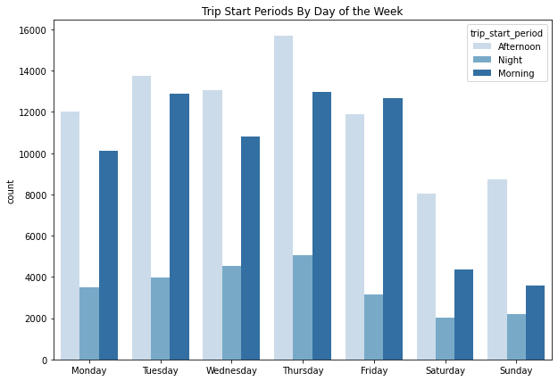

```python
#here we show the distribution of trip start periods over weekdays
plt.figure(figsize=[10,7])
sns.countplot(data=df_clean, x='trip_start_day', hue='trip_start_period',  palette='Blues',
              order=['Monday', 'Tuesday', 'Wednesday', 'Thursday', 'Friday', 'Saturday', 'Sunday'])
plt.title('Trip Start Periods By Day of the Week');
plt.xlabel("");
```

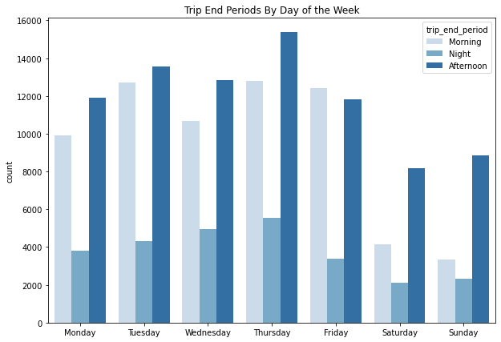

```python
#here we show the distribution of trip end periods over weekdays
plt.figure(figsize=[10,7])
sns.countplot(data=df_clean, x='trip_end_day', hue='trip_end_period',  palette='Blues',
              order=['Monday', 'Tuesday', 'Wednesday', 'Thursday', 'Friday', 'Saturday', 'Sunday'])
plt.title('Trip End Periods By Day of the Week');
plt.xlabel("");
```

> From the plot above we can see some interesting information.
> - We already know that Tuesday and Thursday are the peaked days either for start or end a trip
> - and now we can see that in Tuesday, highest number of users slightly prefer to go on a bike trip in the Afternoon than in the morning and end it in most of the time in the Afternoon
> - while on Thursday they clearly prefer going at the afternoon and end it in the afternoon
> - As Sunday and Saturday have the least number of trips, users in those days prefer to go on a trip and end it in the afternoon, and that probably because it’s the weekend.

> So we can say that globally Afternoon is the peakest period either for start or end a trip for GoBike members

### Trip Duration and members Age

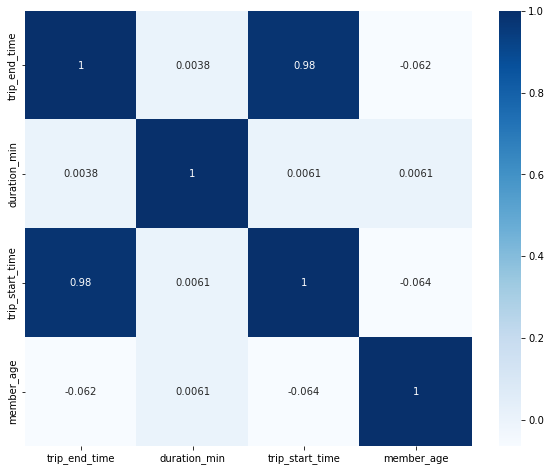

```python
#Here we will check correlations between trip_end_time, duration_min, trip_start_time and member_age
plt.figure(figsize = (10,8))
sns.heatmap(df_clean[['trip_end_time','duration_min', 'trip_start_time','member_age']].corr(),
            annot=True, cmap="Blues");
```

> From the plot above we can see that:
> - There are no correlations between almost all of the features except for trip_start_time and trip_end_time that are highly correlated

### Members Gender and Periods of the day

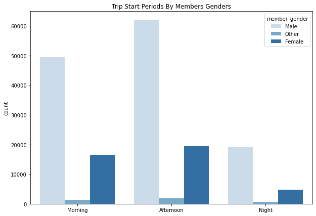

```python
#here we show the distribution of trip start periods over members genders
plt.figure(figsize=[10,7])
sns.countplot(data=df_clean, x='trip_start_period', hue='member_gender', order=['Morning', 'Afternoon', 'Night'],
              palette='Blues')
plt.title('Trip Start Periods By Members Genders');
plt.xlabel("");
```

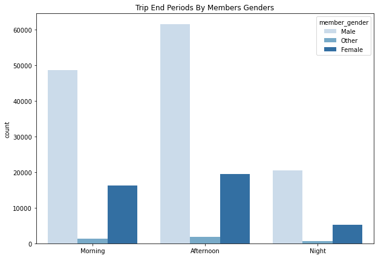

```python
#here we show the distribution of trip end periods over members genders
plt.figure(figsize=[10,7])
sns.countplot(data=df_clean, x='trip_end_period', hue='member_gender', order=['Morning', 'Afternoon', 'Night'],
              palette='Blues')
plt.title('Trip End Periods By Members Genders');
plt.xlabel("");
```

> From the plot above we can see that female and male members do prefer to go on bike trips in the Afternoon more than in Night or in the Morning.

### Trips duration and Users type

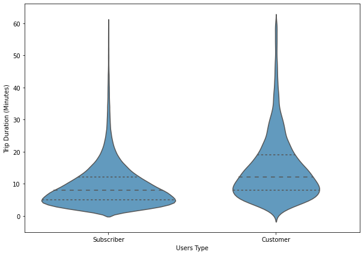

```python
#here we use violinplot to show trip duration distribution over users types
plt.figure(figsize=[10,7])
sns.violinplot(data=df_clean[df_clean['duration_min'] <= 60], x='user_type', y='duration_min',
               color = sns.color_palette('Blues')[3], inner='quartile');
plt.xlabel('Users Type');
plt.ylabel('Trip Duration (Minutes)');
```

> From the plot above we can see that Subscribers tend to have shorter trips compared to casual customers, and it's interesting since subscribers use services more frequently than casual customers and this probably leads to short and quick bike trips.

### Trips durations and Days

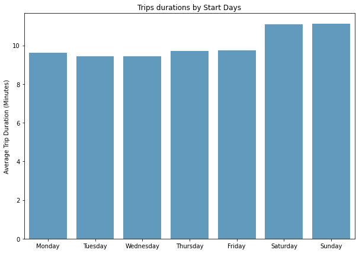

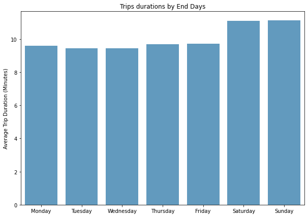

```python
#here we show trips duration distribution by trip start days
plt.figure(figsize=[10,7])
sns.barplot(y='duration_min', x='trip_start_day',data=df_clean[df_clean['duration_min'] <= 60],
            ci=None,
            color = sns.color_palette('Blues')[3],
            order=['Monday', 'Tuesday', 'Wednesday', 'Thursday', 'Friday', 'Saturday', 'Sunday'])
plt.title('Trips durations by Start Days')
plt.ylabel('Average Trip Duration (Minutes)')
plt.xlabel('');
#here we show trips duration distribution by trip end days
plt.figure(figsize=[10,7])
sns.barplot(y='duration_min', x='trip_end_day',data=df_clean[df_clean['duration_min'] <= 60],
            ci=None,
            color = sns.color_palette('Blues')[3],
            order=['Monday', 'Tuesday', 'Wednesday', 'Thursday', 'Friday', 'Saturday', 'Sunday'])
plt.title('Trips durations by End Days')
plt.ylabel('Average Trip Duration (Minutes)')
plt.xlabel('');
```

> From the plot above we can see that on average Weekends (Sunday and Saturday) have longer trips compared to other days and it is close to normal behaviours since people tends to have more free times in weekends.

### Did you observe any interesting relationships between the other features (not the main feature(s) of interest)?

> The days does have an interesting effect on 2 features:
> - the period of the day
> - the trip duration.

Table of contents

## Multivariate Exploration

> Here we will explore relationships between three or more variables

```python
#here we define a function to display a pointplot by taking pointplot parameters
def display_pointplot(title, ylabel, x, y, s, h):
    """He we take pointplot parameters and draw the plot
    """
    plt.figure(figsize=[10,7])
    sns.pointplot(data=df_clean, x=x, y=y, ci=None, hue=h, palette='Blues', scale = s, linestyles="");
    plt.title(title)
    plt.ylabel(ylabel)
    plt.xlabel("");
```

### Average Trip Duration based on Trip Period and Member Gender

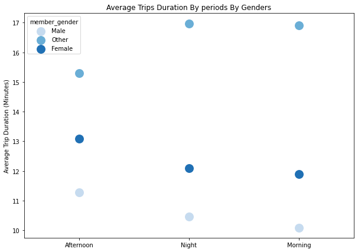

```python
#here we draw a pointplot for average trips duration by periods by genders using the above function
display_pointplot('Average Trips Duration By periods By Genders', 'Average Trip Duration (Minutes)', 'trip_start_period',
                  'duration_min', 1.7, 'member_gender' );
```

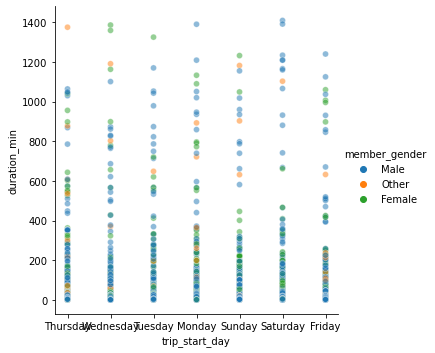

```python
#here we show trip durations by trips start days by members genders
sns.relplot(data=df_clean,
            x="trip_start_day",
            y="duration_min", hue="member_gender",
            alpha = 0.5);
```

### Average Member Age based on Trip Day and User Type

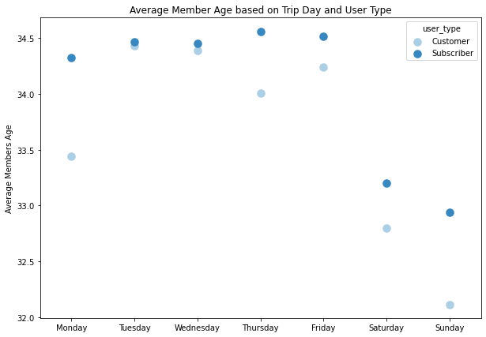

```python
#here we show the average members ages by trip start days by users types
plt.figure(figsize=[10,7])
sns.pointplot(data=df_clean, x='trip_start_day', y='member_age', hue='user_type',
              linestyles="", ci=None,
              scale=1.2, palette='Blues',
              order=['Monday', 'Tuesday', 'Wednesday', 'Thursday', 'Friday', 'Saturday', 'Sunday']);
plt.title('Average Member Age based on Trip Day and User Type');
plt.xlabel("")
plt.ylabel('Average Members Age');
```

> From the plot above we can see that on average younger users both Subscribers and Customers choose to go on trips on the weekends while older users choose workdays for their trips, moreover in general Subscribers are older than Customers.

### Were there any interesting or surprising interactions between features?

> since the features are not huge and straightforward most of the patterns were discovered in previous sections (bivariate and univariate explorations), and the multivariate exploration supported them, so there was no surprising interaction in this section.

table of contents

## Conclusions

At the end of performing all these exploration steps, we found a lot of useful information that can open a lot of future opportunities to improve and promote the business, and summary of the findings:

> GoBike members usually start their trips at:
> - Market St at 10th St
> - San Francisco Caltrain Station 2 (Townsend St at 4th St)
> - Berry St at 4th St

> And usually end their trips at:
> - San Francisco Caltrain Station 2 (Townsend St at 4th St)
> - Market St at 10th St
> - Montgomery St BART Station (Market St at 2nd St)